# FIFA

```python
#NumPy is a Python Library used to perform wide variety of Mathematical Operations on Arrays.
import numpy as np
#Pandas is a Python Library used to analyze big data and make Conclusions based on Stastical Theories.
import pandas as pd
#matplotlib.pyplot contains functions that make matplotlib work like MATLAB and
#each pyplot fuction makes some changes in the figure.
import matplotlib.pyplot as plt
#plotly.express contains functions that can create Entire Figures.
import plotly.express as px
import plotly.graph_objects as go
from plotly.offline import iplot, plot
from plotly.subplots import make_subplots
import seaborn as sns
```

```python
#Loading the Dataset.
Data=pd.read_csv("C:\\Users\\Admin\\Desktop\\Madhu\\Anaconda-Jupyter\\FIFA Jupyter Project\\Raw Data.csv")
```

```python
#To get First 5 Rows of Dataset.
Data.head()
```

|  | SI_NO | Player_URL | Short_Name | Long_Name | Age | Date_of_Birth | Height_cm | Weight_kg | Nationality | Club | ... | lwb | ldm | cdm | rdm | rwb | lb | lcb | cb | rcb | rb |
| --- | --- | --- | --- | --- | --- | --- | --- | --- | --- | --- | --- | --- | --- | --- | --- | --- | --- | --- | --- | --- | --- |
| 0 | 158023 | https://sofifa.com/player/158023/lionel-messi/... | L. Messi | Lionel Andrés Messi Cuccittini | 32 | 6/24/1987 | 170 | 72 | Argentina | FC Barcelona | ... | 68+2 | 66+2 | 66+2 | 66+2 | 68+2 | 63+2 | 52+2 | 52+2 | 52+2 | 63+2 |
| 1 | 20801 | https://sofifa.com/player/20801/c-ronaldo-dos-... | Cristiano Ronaldo | Cristiano Ronaldo dos Santos Aveiro | 34 | 2/5/1985 | 187 | 83 | Portugal | Juventus | ... | 65+3 | 61+3 | 61+3 | 61+3 | 65+3 | 61+3 | 53+3 | 53+3 | 53+3 | 61+3 |
| 2 | 190871 | https://sofifa.com/player/190871/neymar-da-sil... | Neymar Jr | Neymar da Silva Santos Junior | 27 | 2/5/1992 | 175 | 68 | Brazil | Paris Saint-Germain | ... | 66+3 | 61+3 | 61+3 | 61+3 | 66+3 | 61+3 | 46+3 | 46+3 | 46+3 | 61+3 |
| 3 | 200389 | https://sofifa.com/player/200389/jan-oblak/20/... | J. Oblak | Jan Oblak | 26 | 1/7/1993 | 188 | 87 | Slovenia | Atlético Madrid | ... | NaN | NaN | NaN | NaN | NaN | NaN | NaN | NaN | NaN | NaN |
| 4 | 183277 | https://sofifa.com/player/183277/eden-hazard/2... | E. Hazard | Eden Hazard | 28 | 1/7/1991 | 175 | 74 | Belgium | Real Madrid | ... | 66+3 | 63+3 | 63+3 | 63+3 | 66+3 | 61+3 | 49+3 | 49+3 | 49+3 | 61+3 |

5 rows × 104 columns

```python
#To get Last 5 Rows of Dataset.
Data.tail()
```

|  | SI_NO | Player_URL | Short_Name | Long_Name | Age | Date_of_Birth | Height_cm | Weight_kg | Nationality | Club | ... | lwb | ldm | cdm | rdm | rwb | lb | lcb | cb | rcb | rb |
| --- | --- | --- | --- | --- | --- | --- | --- | --- | --- | --- | --- | --- | --- | --- | --- | --- | --- | --- | --- | --- | --- |
| 18273 | 245006 | https://sofifa.com/player/245006/shuai-shao/20... | Shao Shuai | 邵帅 | 22 | 3/10/1997 | 186 | 79 | China PR | Beijing Renhe FC | ... | 43+2 | 42+2 | 42+2 | 42+2 | 43+2 | 45+2 | 46+2 | 46+2 | 46+2 | 45+2 |
| 18274 | 250995 | https://sofifa.com/player/250995/mingjie-xiao/... | Xiao Mingjie | Mingjie Xiao | 22 | 1/1/1997 | 177 | 66 | China PR | Shanghai SIPG FC | ... | 44+2 | 43+2 | 43+2 | 43+2 | 44+2 | 46+2 | 47+2 | 47+2 | 47+2 | 46+2 |
| 18275 | 252332 | https://sofifa.com/player/252332/wei-zhang/20/... | Zhang Wei | 张威 | 19 | 5/16/2000 | 186 | 75 | China PR | Hebei China Fortune FC | ... | 47+2 | 49+2 | 49+2 | 49+2 | 47+2 | 47+2 | 49+2 | 49+2 | 49+2 | 47+2 |
| 18276 | 251110 | https://sofifa.com/player/251110/haijian-wang/... | Wang Haijian | 汪海健 | 18 | 8/2/2000 | 185 | 74 | China PR | Shanghai Greenland Shenhua FC | ... | 48+2 | 48+2 | 48+2 | 48+2 | 48+2 | 48+2 | 49+2 | 49+2 | 49+2 | 48+2 |
| 18277 | 233449 | https://sofifa.com/player/233449/ximing-pan/20... | Pan Ximing | 潘喜明 | 26 | 1/11/1993 | 182 | 78 | China PR | Hebei China Fortune FC | ... | 48+2 | 49+2 | 49+2 | 49+2 | 48+2 | 48+2 | 50+2 | 50+2 | 50+2 | 48+2 |

5 rows × 104 columns

```python
#To get Random 5 Sample Rows from the Dataset
Data.sample(5)
```

|  | SI_NO | Player_URL | Short_Name | Long_Name | Age | Date_of_Birth | Height_cm | Weight_kg | Nationality | Club | ... | lwb | ldm | cdm | rdm | rwb | lb | lcb | cb | rcb | rb |
| --- | --- | --- | --- | --- | --- | --- | --- | --- | --- | --- | --- | --- | --- | --- | --- | --- | --- | --- | --- | --- | --- |
| 17077 | 243353 | https://sofifa.com/player/243353/bali-mumba/20... | B. Mumba | Bali Mumba | 17 | 10/8/2001 | 163 | 57 | England | Sunderland | ... | 54+2 | 55+2 | 55+2 | 55+2 | 54+2 | 54+2 | 54+2 | 54+2 | 54+2 | 54+2 |
| 396 | 191202 | https://sofifa.com/player/191202/nemanja-matic... | N. Matić | Nemanja Matić | 30 | 8/1/1988 | 194 | 85 | Serbia | Manchester United | ... | 74+3 | 79+3 | 79+3 | 79+3 | 74+3 | 73+3 | 78+3 | 78+3 | 78+3 | 73+3 |
| 16677 | 209330 | https://sofifa.com/player/209330/mathias-fredr... | M. Fredriksen | Mathias Fredriksen | 25 | 4/28/1994 | 170 | 65 | Norway | Mjøndalen IF | ... | 43+2 | 37+2 | 37+2 | 37+2 | 43+2 | 40+2 | 33+2 | 33+2 | 33+2 | 40+2 |
| 7816 | 237662 | https://sofifa.com/player/237662/brooks-lennon... | B. Lennon | Brooks Lennon | 21 | 9/22/1997 | 177 | 70 | United States | Real Salt Lake | ... | 66+2 | 64+2 | 64+2 | 64+2 | 66+2 | 65+2 | 62+2 | 62+2 | 62+2 | 65+2 |
| 17383 | 252178 | https://sofifa.com/player/252178/stephen-wearn... | S. Wearne | Stephen Wearne | 18 | 9/16/2000 | 174 | 71 | England | Middlesbrough | ... | 46+2 | 46+2 | 46+2 | 46+2 | 46+2 | 45+2 | 42+2 | 42+2 | 42+2 | 45+2 |

5 rows × 104 columns

# Checking the Dataset.

```python
#To get Shape and Size of the Data.
Data.info()
```

```
<class 'pandas.core.frame.DataFrame'>
RangeIndex: 18278 entries, 0 to 18277
Columns: 104 entries, SI_NO to rb
dtypes: float64(16), int64(45), object(43)
memory usage: 14.5+ MB
```

```python
#To get the Shape of the Dataset.
Data.shape
```

```
(18278, 104)
```

```python
#To get all the Information regarding the Dataset.
Data.describe()
```

|  | SI_NO | Age | Height_cm | Weight_kg | Overall | Potential | Value_in_Euro | Wages_in_Euro | International_Reputation | Weak_Foot | ... | Mentality_Penalties | Mentality_Composure | Defending_Marking | Defending_Standing_Tackle | Defending_Sliding_Tackle | Goalkeeping_Diving | Goalkeeping_Handling | Goalkeeping_Kicking | Goalkeeping_Positioning | Goalkeeping_Reflexes |
| --- | --- | --- | --- | --- | --- | --- | --- | --- | --- | --- | --- | --- | --- | --- | --- | --- | --- | --- | --- | --- | --- |
| count | 18278.000000 | 18278.000000 | 18278.000000 | 18278.000000 | 18278.000000 | 18278.000000 | 1.827800e+04 | 18278.000000 | 18278.000000 | 18278.000000 | ... | 18278.000000 | 18278.000000 | 18278.000000 | 18278.000000 | 18278.000000 | 18278.000000 | 18278.000000 | 18278.000000 | 18278.000000 | 18278.000000 |
| mean | 219738.864482 | 25.283291 | 181.362184 | 75.276343 | 66.244994 | 71.546887 | 2.484038e+06 | 9456.942773 | 1.103184 | 2.944250 | ... | 48.383357 | 58.528778 | 46.848889 | 47.640333 | 45.606631 | 16.572765 | 16.354853 | 16.212934 | 16.368038 | 16.709924 |
| std | 27960.200461 | 4.656964 | 6.756961 | 7.047744 | 6.949953 | 6.139669 | 5.585481e+06 | 21351.714095 | 0.378861 | 0.664656 | ... | 15.708099 | 11.880840 | 20.091287 | 21.585641 | 21.217734 | 17.738069 | 16.996925 | 16.613665 | 17.136497 | 18.038125 |
| min | 768.000000 | 16.000000 | 156.000000 | 50.000000 | 48.000000 | 49.000000 | 0.000000e+00 | 0.000000 | 1.000000 | 1.000000 | ... | 7.000000 | 12.000000 | 1.000000 | 5.000000 | 3.000000 | 1.000000 | 1.000000 | 1.000000 | 1.000000 | 1.000000 |
| 25% | 204445.500000 | 22.000000 | 177.000000 | 70.000000 | 62.000000 | 67.000000 | 3.250000e+05 | 1000.000000 | 1.000000 | 3.000000 | ... | 39.000000 | 51.000000 | 29.000000 | 27.000000 | 24.000000 | 8.000000 | 8.000000 | 8.000000 | 8.000000 | 8.000000 |
| 50% | 226165.000000 | 25.000000 | 181.000000 | 75.000000 | 66.000000 | 71.000000 | 7.000000e+05 | 3000.000000 | 1.000000 | 3.000000 | ... | 49.000000 | 60.000000 | 52.000000 | 55.000000 | 52.000000 | 11.000000 | 11.000000 | 11.000000 | 11.000000 | 11.000000 |
| 75% | 240795.750000 | 29.000000 | 186.000000 | 80.000000 | 71.000000 | 75.000000 | 2.100000e+06 | 8000.000000 | 1.000000 | 3.000000 | ... | 60.000000 | 67.000000 | 64.000000 | 66.000000 | 64.000000 | 14.000000 | 14.000000 | 14.000000 | 14.000000 | 14.000000 |
| max | 252905.000000 | 42.000000 | 205.000000 | 110.000000 | 94.000000 | 95.000000 | 1.055000e+08 | 565000.000000 | 5.000000 | 5.000000 | ... | 92.000000 | 96.000000 | 94.000000 | 92.000000 | 90.000000 | 90.000000 | 92.000000 | 93.000000 | 91.000000 | 92.000000 |

8 rows × 61 columns

```python
#To check the Null Values in the Dataset.
Data.isnull().sum()
```

```
SI_NO            0
Player_URL       0
Short_Name       0
Long_Name        0
Age              0
              ...
lb            2036
lcb           2036
cb            2036
rcb           2036
rb            2036
Length: 104, dtype: int64
```

# Analysing and Visualizing the Dataset.

1)(i) To get the List of all the Nations based on Players Participited in FIFA.

```python
Nations=Data['Nationality'].value_counts()
Nations
```

```
Nationality
England                1667
Germany                1216
Spain                  1035
France                  984
Argentina               886
                       ...
Liberia                   1
São Tomé & Príncipe       1
Puerto Rico               1
Bahrain                   1
Indonesia                 1
Name: count, Length: 162, dtype: int64
```

1)(ii) To get the List of Top 10 Nations.

```python
Data['Nationality'].value_counts()[0:10]
```

```
Nationality
England        1667
Germany        1216
Spain          1035
France          984
Argentina       886
Brazil          824
Italy           732
Colombia        591
Japan           453
Netherlands     416
Name: count, dtype: int64
```

1)(iii) To Plot the Graph.

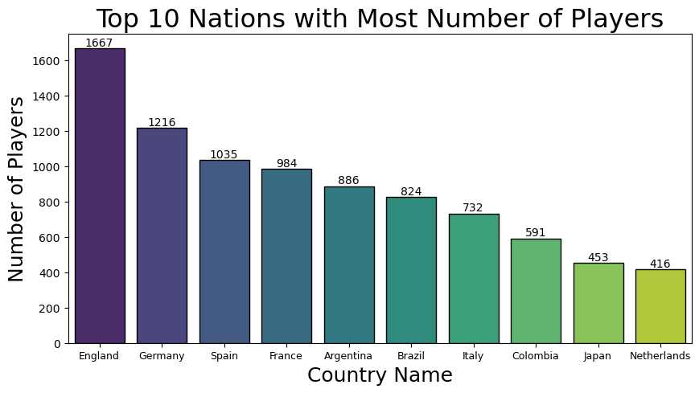

```python
plt.figure(figsize=(10,5))
plt.title('Top 10 Nations with Most Number of Players', color='black', fontsize=23)
plt.xticks(fontsize=9)
plt.yticks(fontsize=10)
plt.xlabel('', fontsize=18)
plt.ylabel('', fontsize=18)
Graph_Data={'Country': Nations.index[:10],
            'No_of_Players': Nations.values[:10]}
Bar_Graph=pd.DataFrame(Graph_Data)
Graph = sns.barplot(x='Country', y='No_of_Players', hue='Country', data=Bar_Graph, palette='viridis', edgecolor='black', dodge=False)
Graph.set(ylabel='Number of Players',xlabel='Country Name')
for container in Graph.containers:
    Graph.bar_label(container, fontsize=10) # To get LABEL on EACH BAR.
plt.show()
```

2)(i) To get the List of Players with their Salary.

```python
Salary=Data[['Short_Name','Wages_in_Euro']]
Salary
```

|  | Short_Name | Wages_in_Euro |
| --- | --- | --- |
| 0 | L. Messi | 565000 |
| 1 | Cristiano Ronaldo | 405000 |
| 2 | Neymar Jr | 290000 |
| 3 | J. Oblak | 125000 |
| 4 | E. Hazard | 470000 |
| ... | ... | ... |
| 18273 | Shao Shuai | 2000 |
| 18274 | Xiao Mingjie | 2000 |
| 18275 | Zhang Wei | 1000 |
| 18276 | Wang Haijian | 1000 |
| 18277 | Pan Ximing | 2000 |

18278 rows × 2 columns

2)(ii) To get the List of Top 10 Players with HIGHEST SALARY.

```python
Player_Salary=Salary.sort_values(by=['Wages_in_Euro'],ascending=False).head(10)
Player_Salary
```

|  | Short_Name | Wages_in_Euro |
| --- | --- | --- |
| 0 | L. Messi | 565000 |
| 4 | E. Hazard | 470000 |
| 1 | Cristiano Ronaldo | 405000 |
| 5 | K. De Bruyne | 370000 |
| 22 | A. Griezmann | 370000 |
| 19 | L. Suárez | 355000 |
| 8 | L. Modrić | 340000 |
| 36 | T. Kroos | 330000 |
| 17 | S. Agüero | 300000 |
| 21 | Sergio Busquets | 300000 |

2)(iii) To Plot the Graph.

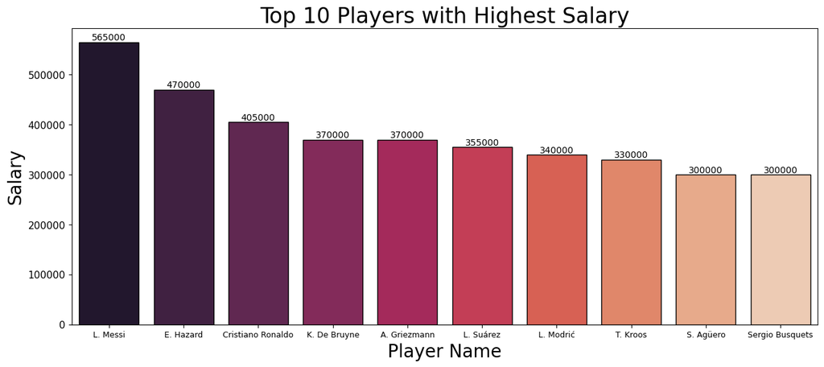

```python
plt.figure(figsize=(15,6))
plt.title('Top 10 Players with Highest Salary', color='black', fontsize=24)
plt.xticks(fontsize=9)
plt.yticks(fontsize=11)
plt.xlabel('', fontsize=20)
plt.ylabel('', fontsize=20)
Bar_Graph = pd.DataFrame(Player_Salary)
Graph = sns.barplot(x='Short_Name', y='Wages_in_Euro', hue='Short_Name', data=Bar_Graph, palette='rocket', edgecolor='black', dodge=False)
Graph.set(ylabel='Salary', xlabel='Player Name')
for container in Graph.containers:
    Graph.bar_label(container, fontsize=10)  # To get LABEL on EACH BAR.
plt.show()
```

3)(i) To get the List of Players with their Height in cm.

```python
Height=Data[['Short_Name','Height_cm']]
Height
```

|  | Short_Name | Height_cm |
| --- | --- | --- |
| 0 | L. Messi | 170 |
| 1 | Cristiano Ronaldo | 187 |
| 2 | Neymar Jr | 175 |
| 3 | J. Oblak | 188 |
| 4 | E. Hazard | 175 |
| ... | ... | ... |
| 18273 | Shao Shuai | 186 |
| 18274 | Xiao Mingjie | 177 |
| 18275 | Zhang Wei | 186 |
| 18276 | Wang Haijian | 185 |
| 18277 | Pan Ximing | 182 |

18278 rows × 2 columns

3)(ii) To get the List of Top 10 Tallest Players.

```python
Player_Height=Height.sort_values(by=['Height_cm'],ascending=False).head(10)
Player_Height
```

|  | Short_Name | Height_cm |
| --- | --- | --- |
| 9208 | T. Holý | 205 |
| 8200 | A. Ba | 203 |
| 12808 | A. Chapman | 203 |
| 3121 | C. Pantilimon | 203 |
| 12864 | M. Qvist | 203 |
| 17365 | M. Casey | 203 |
| 5451 | L. Traoré | 203 |
| 17149 | S. Brolin | 202 |
| 4868 | V. Milinković-Savić | 202 |
| 7725 | K. Scherpen | 202 |

3)(iii) To get the List of Top 10 Shortest Players.

```python
Player_Height=Height.sort_values(by=['Height_cm'],ascending=True).head(10)
Player_Height
```

|  | Short_Name | Height_cm |
| --- | --- | --- |
| 4829 | N. Barrios | 156 |
| 3898 | J. Plata | 157 |
| 16929 | J. Nisbet | 158 |
| 1496 | M. Moralez | 158 |
| 4243 | C. Songkrasin | 158 |
| 6789 | M. Domínguez | 159 |
| 15878 | J. Romero | 159 |
| 4552 | D. Villalva | 159 |
| 6541 | E. Oztumer | 160 |
| 12549 | Kim Hyeon Wook | 160 |

4)(i) To get all the Details of Nation-INDIA in FIFA.

```python
India=Data[Data['Nationality']=='India']
India
```

|  | SI_NO | Player_URL | Short_Name | Long_Name | Age | Date_of_Birth | Height_cm | Weight_kg | Nationality | Club | ... | lwb | ldm | cdm | rdm | rwb | lb | lcb | cb | rcb | rb |
| --- | --- | --- | --- | --- | --- | --- | --- | --- | --- | --- | --- | --- | --- | --- | --- | --- | --- | --- | --- | --- | --- |
| 12155 | 251742 | https://sofifa.com/player/251742/gajodara-chat... | G. Chatterjee | Gajodara Chatterjee | 33 | 7/4/1985 | 195 | 84 | India | India | ... | NaN | NaN | NaN | NaN | NaN | NaN | NaN | NaN | NaN | NaN |
| 13102 | 251723 | https://sofifa.com/player/251723/prakul-bhatt/... | P. Bhatt | Prakul Bhatt | 34 | 4/7/1985 | 182 | 78 | India | India | ... | 47+2 | 46+2 | 46+2 | 46+2 | 47+2 | 46+2 | 44+2 | 44+2 | 44+2 | 46+2 |
| 13103 | 251728 | https://sofifa.com/player/251728/bhadrashree-r... | B. Raj | Bhadrashree Raj | 31 | 3/25/1988 | 175 | 69 | India | India | ... | 61+2 | 58+2 | 58+2 | 58+2 | 61+2 | 61+2 | 59+2 | 59+2 | 59+2 | 61+2 |
| 13970 | 251722 | https://sofifa.com/player/251722/abhimoda-chak... | A. Chakraborty | Abhimoda Chakraborty | 33 | 10/27/1985 | 189 | 79 | India | India | ... | 53+2 | 57+2 | 57+2 | 57+2 | 53+2 | 54+2 | 61+2 | 61+2 | 61+2 | 54+2 |
| 13971 | 251727 | https://sofifa.com/player/251727/hantidev-bhan... | H. Bhandari | Hantidev Bhandari | 30 | 6/22/1989 | 178 | 74 | India | India | ... | 53+2 | 51+2 | 51+2 | 51+2 | 53+2 | 51+2 | 47+2 | 47+2 | 47+2 | 51+2 |
| 13972 | 251736 | https://sofifa.com/player/251736/anvit-swamina... | A. Swaminathan | Anvit Swaminathan | 27 | 10/29/1991 | 173 | 65 | India | India | ... | 47+2 | 45+2 | 45+2 | 45+2 | 47+2 | 44+2 | 37+2 | 37+2 | 37+2 | 44+2 |
| 14625 | 251729 | https://sofifa.com/player/251729/devindra-pill... | D. Pillai | Devindra Pillai | 31 | 6/22/1988 | 178 | 70 | India | India | ... | 57+2 | 55+2 | 55+2 | 55+2 | 57+2 | 56+2 | 51+2 | 51+2 | 51+2 | 56+2 |
| 15204 | 251743 | https://sofifa.com/player/251743/adit-ginti/20... | A. Ginti | Adit Ginti | 25 | 8/10/1993 | 170 | 69 | India | India | ... | 59+2 | 54+2 | 54+2 | 54+2 | 59+2 | 59+2 | 55+2 | 55+2 | 55+2 | 59+2 |
| 15205 | 251747 | https://sofifa.com/player/251747/anuvinda-khur... | A. Khurana | Anuvinda Khurana | 26 | 4/21/1993 | 186 | 81 | India | India | ... | 51+2 | 54+2 | 54+2 | 54+2 | 51+2 | 53+2 | 59+2 | 59+2 | 59+2 | 53+2 |
| 15321 | 251721 | https://sofifa.com/player/251721/attana-deshpa... | A. Deshpande | Attana Deshpande | 38 | 12/17/1980 | 180 | 76 | India | India | ... | 48+2 | 49+2 | 49+2 | 49+2 | 48+2 | 44+2 | 42+2 | 42+2 | 42+2 | 44+2 |
| 15322 | 251725 | https://sofifa.com/player/251725/tapish-atwal/... | T. Atwal | Tapish Atwal | 35 | 9/28/1983 | 181 | 77 | India | India | ... | 53+2 | 56+2 | 56+2 | 56+2 | 53+2 | 54+2 | 59+2 | 59+2 | 59+2 | 54+2 |
| 15323 | 251731 | https://sofifa.com/player/251731/bismeet-sidhu... | B. Sidhu | Bismeet Sidhu | 31 | 8/20/1987 | 171 | 68 | India | India | ... | 59+2 | 58+2 | 58+2 | 58+2 | 59+2 | 58+2 | 55+2 | 55+2 | 55+2 | 58+2 |
| 15324 | 251732 | https://sofifa.com/player/251732/remil-nadkarn... | R. Nadkarni | Remil Nadkarni | 33 | 10/31/1985 | 180 | 70 | India | India | ... | 46+2 | 44+2 | 44+2 | 44+2 | 46+2 | 43+2 | 38+2 | 38+2 | 38+2 | 43+2 |
| 15809 | 251739 | https://sofifa.com/player/251739/vihaan-boral/... | V. Boral | Vihaan Boral | 29 | 7/14/1989 | 183 | 77 | India | India | ... | NaN | NaN | NaN | NaN | NaN | NaN | NaN | NaN | NaN | NaN |
| 15866 | 251726 | https://sofifa.com/player/251726/diasha-sundar... | D. Sundaram | Diasha Sundaram | 30 | 4/28/1989 | 186 | 81 | India | India | ... | 53+2 | 54+2 | 54+2 | 54+2 | 53+2 | 54+2 | 58+2 | 58+2 | 58+2 | 54+2 |
| 15867 | 251746 | https://sofifa.com/player/251746/randhir-jayar... | R. Jayaraman | Randhir Jayaraman | 34 | 11/20/1984 | 180 | 82 | India | India | ... | 43+2 | 43+2 | 43+2 | 43+2 | 43+2 | 41+2 | 44+2 | 44+2 | 44+2 | 41+2 |
| 15868 | 251748 | https://sofifa.com/player/251748/dinkerrai-baj... | D. Bajwa | Dinkerrai Bajwa | 38 | 3/5/1981 | 182 | 72 | India | India | ... | 55+2 | 58+2 | 58+2 | 58+2 | 55+2 | 56+2 | 60+2 | 60+2 | 60+2 | 56+2 |
| 16300 | 251749 | https://sofifa.com/player/251749/omesh-patla/2... | O. Patla | Omesh Patla | 26 | 10/13/1992 | 167 | 69 | India | India | ... | 56+2 | 53+2 | 53+2 | 53+2 | 56+2 | 55+2 | 49+2 | 49+2 | 49+2 | 55+2 |
| 16303 | 251733 | https://sofifa.com/player/251733/palkesh-nagar... | P. Nagarajan | Palkesh Nagarajan | 29 | 10/12/1989 | 189 | 87 | India | India | ... | NaN | NaN | NaN | NaN | NaN | NaN | NaN | NaN | NaN | NaN |
| 16352 | 251724 | https://sofifa.com/player/251724/taranjot-agar... | T. Agarwal | Taranjot Agarwal | 33 | 2/15/1986 | 173 | 68 | India | India | ... | 57+2 | 54+2 | 54+2 | 54+2 | 57+2 | 56+2 | 54+2 | 54+2 | 54+2 | 56+2 |
| 16353 | 251735 | https://sofifa.com/player/251735/amanpreet-var... | A. Varkay | Amanpreet Varkay | 33 | 8/18/1985 | 179 | 71 | India | India | ... | 57+2 | 56+2 | 56+2 | 56+2 | 57+2 | 57+2 | 57+2 | 57+2 | 57+2 | 57+2 |
| 16354 | 251745 | https://sofifa.com/player/251745/chapal-palan/... | C. Palan | Chapal Palan | 28 | 6/20/1991 | 181 | 69 | India | India | ... | 60+2 | 59+2 | 59+2 | 59+2 | 60+2 | 61+2 | 61+2 | 61+2 | 61+2 | 61+2 |
| 16714 | 251750 | https://sofifa.com/player/251750/dhwanil-singh... | D. Singhal | Dhwanil Singhal | 34 | 11/9/1984 | 177 | 71 | India | India | ... | 57+2 | 56+2 | 56+2 | 56+2 | 57+2 | 57+2 | 57+2 | 57+2 | 57+2 | 57+2 |

23 rows × 104 columns

4)(ii) To get all the Details of Indian Players based on their Height.

```python
India.sort_values(by=['Height_cm'],ascending=False).head()
```

|  | SI_NO | Player_URL | Short_Name | Long_Name | Age | Date_of_Birth | Height_cm | Weight_kg | Nationality | Club | ... | lwb | ldm | cdm | rdm | rwb | lb | lcb | cb | rcb | rb |
| --- | --- | --- | --- | --- | --- | --- | --- | --- | --- | --- | --- | --- | --- | --- | --- | --- | --- | --- | --- | --- | --- |
| 12155 | 251742 | https://sofifa.com/player/251742/gajodara-chat... | G. Chatterjee | Gajodara Chatterjee | 33 | 7/4/1985 | 195 | 84 | India | India | ... | NaN | NaN | NaN | NaN | NaN | NaN | NaN | NaN | NaN | NaN |
| 13970 | 251722 | https://sofifa.com/player/251722/abhimoda-chak... | A. Chakraborty | Abhimoda Chakraborty | 33 | 10/27/1985 | 189 | 79 | India | India | ... | 53+2 | 57+2 | 57+2 | 57+2 | 53+2 | 54+2 | 61+2 | 61+2 | 61+2 | 54+2 |
| 16303 | 251733 | https://sofifa.com/player/251733/palkesh-nagar... | P. Nagarajan | Palkesh Nagarajan | 29 | 10/12/1989 | 189 | 87 | India | India | ... | NaN | NaN | NaN | NaN | NaN | NaN | NaN | NaN | NaN | NaN |
| 15205 | 251747 | https://sofifa.com/player/251747/anuvinda-khur... | A. Khurana | Anuvinda Khurana | 26 | 4/21/1993 | 186 | 81 | India | India | ... | 51+2 | 54+2 | 54+2 | 54+2 | 51+2 | 53+2 | 59+2 | 59+2 | 59+2 | 53+2 |
| 15866 | 251726 | https://sofifa.com/player/251726/diasha-sundar... | D. Sundaram | Diasha Sundaram | 30 | 4/28/1989 | 186 | 81 | India | India | ... | 53+2 | 54+2 | 54+2 | 54+2 | 53+2 | 54+2 | 58+2 | 58+2 | 58+2 | 54+2 |

5 rows × 104 columns

4)(iii) To get all the Details of Indian Players based on their Weight.

```python
India.sort_values(by=['Weight_kg'],ascending=False).head()
```

|  | SI_NO | Player_URL | Short_Name | Long_Name | Age | Date_of_Birth | Height_cm | Weight_kg | Nationality | Club | ... | lwb | ldm | cdm | rdm | rwb | lb | lcb | cb | rcb | rb |
| --- | --- | --- | --- | --- | --- | --- | --- | --- | --- | --- | --- | --- | --- | --- | --- | --- | --- | --- | --- | --- | --- |
| 16303 | 251733 | https://sofifa.com/player/251733/palkesh-nagar... | P. Nagarajan | Palkesh Nagarajan | 29 | 10/12/1989 | 189 | 87 | India | India | ... | NaN | NaN | NaN | NaN | NaN | NaN | NaN | NaN | NaN | NaN |
| 12155 | 251742 | https://sofifa.com/player/251742/gajodara-chat... | G. Chatterjee | Gajodara Chatterjee | 33 | 7/4/1985 | 195 | 84 | India | India | ... | NaN | NaN | NaN | NaN | NaN | NaN | NaN | NaN | NaN | NaN |
| 15867 | 251746 | https://sofifa.com/player/251746/randhir-jayar... | R. Jayaraman | Randhir Jayaraman | 34 | 11/20/1984 | 180 | 82 | India | India | ... | 43+2 | 43+2 | 43+2 | 43+2 | 43+2 | 41+2 | 44+2 | 44+2 | 44+2 | 41+2 |
| 15205 | 251747 | https://sofifa.com/player/251747/anuvinda-khur... | A. Khurana | Anuvinda Khurana | 26 | 4/21/1993 | 186 | 81 | India | India | ... | 51+2 | 54+2 | 54+2 | 54+2 | 51+2 | 53+2 | 59+2 | 59+2 | 59+2 | 53+2 |
| 15866 | 251726 | https://sofifa.com/player/251726/diasha-sundar... | D. Sundaram | Diasha Sundaram | 30 | 4/28/1989 | 186 | 81 | India | India | ... | 53+2 | 54+2 | 54+2 | 54+2 | 53+2 | 54+2 | 58+2 | 58+2 | 58+2 | 54+2 |

5 rows × 104 columns

4)(iv) To get the List of Indian Players based on their Salary.

```python
India[['Short_Name','Wages_in_Euro']].sort_values(by=['Wages_in_Euro'])
```

|  | Short_Name | Wages_in_Euro |
| --- | --- | --- |
| 12155 | G. Chatterjee | 0 |
| 16353 | A. Varkay | 0 |
| 16352 | T. Agarwal | 0 |
| 16303 | P. Nagarajan | 0 |
| 16300 | O. Patla | 0 |
| 15868 | D. Bajwa | 0 |
| 15867 | R. Jayaraman | 0 |
| 15866 | D. Sundaram | 0 |
| 15809 | V. Boral | 0 |
| 15324 | R. Nadkarni | 0 |
| 16354 | C. Palan | 0 |
| 15323 | B. Sidhu | 0 |
| 15321 | A. Deshpande | 0 |
| 15205 | A. Khurana | 0 |
| 15204 | A. Ginti | 0 |
| 14625 | D. Pillai | 0 |
| 13972 | A. Swaminathan | 0 |
| 13971 | H. Bhandari | 0 |
| 13970 | A. Chakraborty | 0 |
| 13103 | B. Raj | 0 |
| 13102 | P. Bhatt | 0 |
| 15322 | T. Atwal | 0 |
| 16714 | D. Singhal | 0 |

5)(i) To get all the Details of Nation-ARGENTINA in FIFA.

```python
Argentina=Data[Data['Nationality']=='Argentina']
Argentina
```

|  | SI_NO | Player_URL | Short_Name | Long_Name | Age | Date_of_Birth | Height_cm | Weight_kg | Nationality | Club | ... | lwb | ldm | cdm | rdm | rwb | lb | lcb | cb | rcb | rb |
| --- | --- | --- | --- | --- | --- | --- | --- | --- | --- | --- | --- | --- | --- | --- | --- | --- | --- | --- | --- | --- | --- |
| 0 | 158023 | https://sofifa.com/player/158023/lionel-messi/... | L. Messi | Lionel Andrés Messi Cuccittini | 32 | 6/24/1987 | 170 | 72 | Argentina | FC Barcelona | ... | 68+2 | 66+2 | 66+2 | 66+2 | 68+2 | 63+2 | 52+2 | 52+2 | 52+2 | 63+2 |
| 17 | 153079 | https://sofifa.com/player/153079/sergio-aguero... | S. Agüero | Sergio Leonel Agüero del Castillo | 31 | 6/2/1988 | 173 | 70 | Argentina | Manchester City | ... | 60+3 | 58+3 | 58+3 | 58+3 | 60+3 | 56+3 | 50+3 | 50+3 | 50+3 | 56+3 |
| 23 | 211110 | https://sofifa.com/player/211110/paulo-dybala/... | P. Dybala | Paulo Bruno Exequiel Dybala | 25 | 11/15/1993 | 177 | 75 | Argentina | Juventus | ... | 68+3 | 64+3 | 64+3 | 64+3 | 68+3 | 64+3 | 54+3 | 54+3 | 54+3 | 64+3 |
| 66 | 183898 | https://sofifa.com/player/183898/angel-di-mari... | A. Di María | Ángel Fabián Di María Hernández | 31 | 2/14/1988 | 180 | 69 | Argentina | Paris Saint-Germain | ... | 69+3 | 66+3 | 66+3 | 66+3 | 69+3 | 66+3 | 57+3 | 57+3 | 57+3 | 66+3 |
| 93 | 201399 | https://sofifa.com/player/201399/mauro-icardi/... | M. Icardi | Mauro Emanuel Icardi Rivero | 26 | 2/19/1993 | 181 | 75 | Argentina | Inter | ... | 53+3 | 52+3 | 52+3 | 52+3 | 53+3 | 51+3 | 50+3 | 50+3 | 50+3 | 51+3 |
| ... | ... | ... | ... | ... | ... | ... | ... | ... | ... | ... | ... | ... | ... | ... | ... | ... | ... | ... | ... | ... | ... |
| 17526 | 247295 | https://sofifa.com/player/247295/joaquin-hass/... | J. Hass | Joaquín Hass | 21 | 3/27/1998 | 186 | 88 | Argentina | Club Atlético Colón | ... | NaN | NaN | NaN | NaN | NaN | NaN | NaN | NaN | NaN | NaN |
| 17580 | 197770 | https://sofifa.com/player/197770/gerardo-bruna... | G. Bruna | Gerardo Alfredo Bruna Blanco | 28 | 2/21/1991 | 170 | 64 | Argentina | Derry City | ... | 45+2 | 43+2 | 43+2 | 43+2 | 45+2 | 42+2 | 36+2 | 36+2 | 36+2 | 42+2 |
| 17657 | 245057 | https://sofifa.com/player/245057/rafael-ferrar... | R. Ferrario | Rafael Ferrario | 19 | 4/30/2000 | 186 | 76 | Argentina | Club Atlético Huracán | ... | NaN | NaN | NaN | NaN | NaN | NaN | NaN | NaN | NaN | NaN |
| 17712 | 241099 | https://sofifa.com/player/241099/leandro-finoc... | L. Finochietto | Leandro Finochietto | 22 | 4/25/1997 | 186 | 77 | Argentina | Argentinos Juniors | ... | NaN | NaN | NaN | NaN | NaN | NaN | NaN | NaN | NaN | NaN |
| 17922 | 246841 | https://sofifa.com/player/246841/nicolas-foras... | N. Forastiero | Nicolás Forastiero | 20 | 7/16/1998 | 182 | 79 | Argentina | Argentinos Juniors | ... | NaN | NaN | NaN | NaN | NaN | NaN | NaN | NaN | NaN | NaN |

886 rows × 104 columns

5)(ii) To get all the Details of Argentina Players based on their Height.

```python
Argentina.sort_values(by=['Height_cm'],ascending=False).head()
```

|  | SI_NO | Player_URL | Short_Name | Long_Name | Age | Date_of_Birth | Height_cm | Weight_kg | Nationality | Club | ... | lwb | ldm | cdm | rdm | rwb | lb | lcb | cb | rcb | rb |
| --- | --- | --- | --- | --- | --- | --- | --- | --- | --- | --- | --- | --- | --- | --- | --- | --- | --- | --- | --- | --- | --- |
| 6542 | 223071 | https://sofifa.com/player/223071/fernando-pell... | F. Pellegrino | Fernando Pellegrino | 33 | 3/31/1986 | 197 | 90 | Argentina | Club Atlético Huracán | ... | NaN | NaN | NaN | NaN | NaN | NaN | NaN | NaN | NaN | NaN |
| 6067 | 222889 | https://sofifa.com/player/222889/lucas-acevedo... | L. Acevedo | Lucas Acevedo | 27 | 11/8/1991 | 197 | 97 | Argentina | Club Atlético Colón | ... | 56+2 | 61+2 | 61+2 | 61+2 | 56+2 | 59+2 | 68+2 | 68+2 | 68+2 | 59+2 |
| 1786 | 205186 | https://sofifa.com/player/205186/paulo-gazzani... | P. Gazzaniga | Paulo Dino Gazzaniga | 27 | 1/2/1992 | 196 | 90 | Argentina | Tottenham Hotspur | ... | NaN | NaN | NaN | NaN | NaN | NaN | NaN | NaN | NaN | NaN |
| 1141 | 152993 | https://sofifa.com/player/152993/renato-civell... | R. Civelli | Renato Civelli | 35 | 10/14/1983 | 195 | 89 | Argentina | Club Atlético Banfield | ... | 62+2 | 70+2 | 70+2 | 70+2 | 62+2 | 65+2 | 75+2 | 75+2 | 75+2 | 65+2 |
| 519 | 179847 | https://sofifa.com/player/179847/federico-fazi... | F. Fazio | Federico Julián Fazio | 32 | 3/17/1987 | 195 | 85 | Argentina | Roma | ... | 65+3 | 73+3 | 73+3 | 73+3 | 65+3 | 68+3 | 79+3 | 79+3 | 79+3 | 68+3 |

5 rows × 104 columns

5)(iii) To get all the Details of Argentina Players based on their Weight.

```python
Argentina.sort_values(by=['Weight_kg'],ascending=False).head()
```

|  | SI_NO | Player_URL | Short_Name | Long_Name | Age | Date_of_Birth | Height_cm | Weight_kg | Nationality | Club | ... | lwb | ldm | cdm | rdm | rwb | lb | lcb | cb | rcb | rb |
| --- | --- | --- | --- | --- | --- | --- | --- | --- | --- | --- | --- | --- | --- | --- | --- | --- | --- | --- | --- | --- | --- |
| 9006 | 235925 | https://sofifa.com/player/235925/gaston-gomez/... | G. Gómez | Gastón Gómez | 23 | 3/4/1996 | 190 | 99 | Argentina | Racing Club | ... | NaN | NaN | NaN | NaN | NaN | NaN | NaN | NaN | NaN | NaN |
| 6067 | 222889 | https://sofifa.com/player/222889/lucas-acevedo... | L. Acevedo | Lucas Acevedo | 27 | 11/8/1991 | 197 | 97 | Argentina | Club Atlético Colón | ... | 56+2 | 61+2 | 61+2 | 61+2 | 56+2 | 59+2 | 68+2 | 68+2 | 68+2 | 59+2 |
| 2174 | 227275 | https://sofifa.com/player/227275/agustin-rossi... | A. Rossi | Agustín Daniel Rossi | 23 | 8/21/1995 | 193 | 95 | Argentina | Club Atlético Lanús | ... | NaN | NaN | NaN | NaN | NaN | NaN | NaN | NaN | NaN | NaN |
| 682 | 176919 | https://sofifa.com/player/176919/nahuel-guzman... | N. Guzmán | Nahuel Ignacio Guzmán | 33 | 2/10/1986 | 193 | 94 | Argentina | Tigres U.A.N.L. | ... | NaN | NaN | NaN | NaN | NaN | NaN | NaN | NaN | NaN | NaN |
| 792 | 214979 | https://sofifa.com/player/214979/juan-musso/20... | J. Musso | Juan Musso | 25 | 5/6/1994 | 191 | 93 | Argentina | Udinese | ... | NaN | NaN | NaN | NaN | NaN | NaN | NaN | NaN | NaN | NaN |

5 rows × 104 columns

5)(iv) To get the List of Top 10 Argentina Players based on their Salary.

```python
Argentina_Top_10=Argentina[['Short_Name','Wages_in_Euro']].sort_values(by=['Wages_in_Euro'],ascending=False).head(10)
Argentina_Top_10
```

|  | Short_Name | Wages_in_Euro |
| --- | --- | --- |
| 0 | L. Messi | 565000 |
| 17 | S. Agüero | 300000 |
| 23 | P. Dybala | 215000 |
| 98 | G. Higuaín | 175000 |
| 66 | A. Di María | 150000 |
| 224 | N. Otamendi | 145000 |
| 93 | M. Icardi | 115000 |
| 159 | G. Lo Celso | 105000 |
| 957 | M. Rojo | 95000 |
| 504 | E. Lamela | 94000 |

5)(v) To plot the Graph.

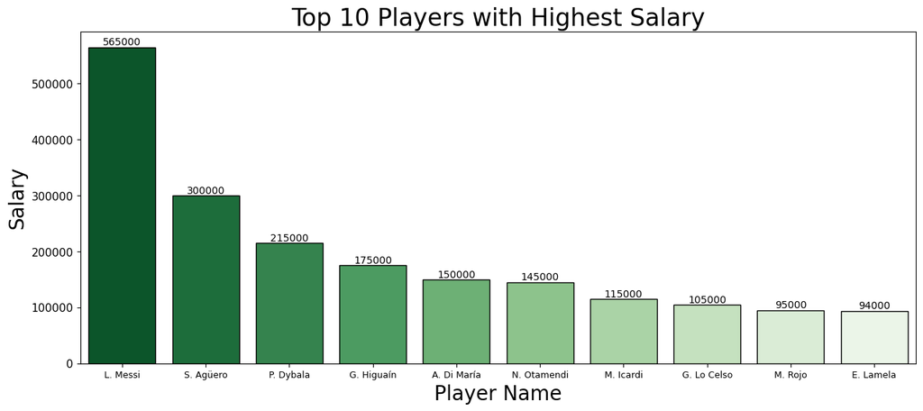

```python
plt.figure(figsize=(15,6))
plt.title('Top 10 Players with Highest Salary', color='black', fontsize=24)
plt.xticks(fontsize=9)
plt.yticks(fontsize=11)
plt.xlabel('', fontsize=20)
plt.ylabel('', fontsize=20)
Bar_Graph = pd.DataFrame(Argentina_Top_10)
Graph = sns.barplot(x='Short_Name', y='Wages_in_Euro', hue='Short_Name', data=Bar_Graph, palette='Greens_r', edgecolor='black', dodge=False)
Graph.set(ylabel='Salary', xlabel='Player Name')
for container in Graph.containers:
    Graph.bar_label(container, fontsize=10)  # To get LABEL on EACH BAR.
plt.show()
```

6)(i) To get all the Details of Nation-PORTUGAL in FIFA.

```python
Portugal=Data[Data['Nationality']=='Portugal']
Portugal
```

|  | SI_NO | Player_URL | Short_Name | Long_Name | Age | Date_of_Birth | Height_cm | Weight_kg | Nationality | Club | ... | lwb | ldm | cdm | rdm | rwb | lb | lcb | cb | rcb | rb |
| --- | --- | --- | --- | --- | --- | --- | --- | --- | --- | --- | --- | --- | --- | --- | --- | --- | --- | --- | --- | --- | --- |
| 1 | 20801 | https://sofifa.com/player/20801/c-ronaldo-dos-... | Cristiano Ronaldo | Cristiano Ronaldo dos Santos Aveiro | 34 | 2/5/1985 | 187 | 83 | Portugal | Juventus | ... | 65+3 | 61+3 | 61+3 | 61+3 | 65+3 | 61+3 | 53+3 | 53+3 | 53+3 | 61+3 |
| 41 | 218667 | https://sofifa.com/player/218667/bernardo-mota... | Bernardo Silva | Bernardo Mota Veiga de Carvalho e Silva | 24 | 8/10/1994 | 173 | 64 | Portugal | Manchester City | ... | 72+2 | 69+2 | 69+2 | 69+2 | 72+2 | 67+2 | 57+2 | 57+2 | 57+2 | 67+2 |
| 85 | 212198 | https://sofifa.com/player/212198/bruno-miguel-... | Bruno Fernandes | Bruno Miguel Borges Fernandes | 24 | 9/8/1994 | 179 | 69 | Portugal | Sporting CP | ... | 77+2 | 77+2 | 77+2 | 77+2 | 77+2 | 74+2 | 68+2 | 68+2 | 68+2 | 74+2 |
| 86 | 199482 | https://sofifa.com/player/199482/anthony-lopes... | A. Lopes | Anthony Lopes | 28 | 10/1/1990 | 184 | 81 | Portugal | Olympique Lyonnais | ... | NaN | NaN | NaN | NaN | NaN | NaN | NaN | NaN | NaN | NaN |
| 112 | 210514 | https://sofifa.com/player/210514/joao-pedro-ca... | João Cancelo | João Pedro Cavaco Cancelo | 25 | 5/27/1994 | 182 | 74 | Portugal | Manchester City | ... | 83+2 | 79+2 | 79+2 | 79+2 | 83+2 | 82+2 | 76+2 | 76+2 | 76+2 | 82+2 |
| ... | ... | ... | ... | ... | ... | ... | ... | ... | ... | ... | ... | ... | ... | ... | ... | ... | ... | ... | ... | ... | ... |
| 16006 | 234571 | https://sofifa.com/player/234571/mesaque-gerem... | Mésaque Djú | Mésaque Geremias Djú | 20 | 3/18/1999 | 178 | 63 | Portugal | West Ham United | ... | 44+2 | 41+2 | 41+2 | 41+2 | 44+2 | 43+2 | 40+2 | 40+2 | 40+2 | 43+2 |
| 16299 | 251576 | https://sofifa.com/player/251576/danny-esteves... | Danny Esteves | Danny Esteves | 24 | 7/29/1994 | 176 | 78 | Portugal | Academica Clinceni | ... | 42+2 | 37+2 | 37+2 | 37+2 | 42+2 | 39+2 | 32+2 | 32+2 | 32+2 | 39+2 |
| 16313 | 252133 | https://sofifa.com/player/252133/wilson-robert... | Wilson Carvalho | Wilson Roberto Bento De Carvalho | 25 | 7/4/1993 | 183 | 77 | Portugal | Accrington Stanley | ... | 51+2 | 47+2 | 47+2 | 47+2 | 51+2 | 50+2 | 45+2 | 45+2 | 45+2 | 50+2 |
| 17754 | 248767 | https://sofifa.com/player/248767/a-pimenta-flo... | Alexandre Pimenta | A. Pimenta Flora Pimenta | 20 | 3/2/1999 | 184 | 75 | Portugal | Venezia FC | ... | 40+2 | 36+2 | 36+2 | 36+2 | 40+2 | 38+2 | 32+2 | 32+2 | 32+2 | 38+2 |
| 17780 | 246312 | https://sofifa.com/player/246312/fabio-lopes/2... | Fabio Lopes | Fabio Lopes | 17 | 12/7/2001 | 175 | 59 | Portugal | Oxford United | ... | 37+2 | 32+2 | 32+2 | 32+2 | 37+2 | 35+2 | 27+2 | 27+2 | 27+2 | 35+2 |

344 rows × 104 columns

6)(ii) To get all the Details of Portugal Players based on their Height.

```python
Portugal.sort_values(by=['Height_cm'],ascending=False).head()
```

|  | SI_NO | Player_URL | Short_Name | Long_Name | Age | Date_of_Birth | Height_cm | Weight_kg | Nationality | Club | ... | lwb | ldm | cdm | rdm | rwb | lb | lcb | cb | rcb | rb |
| --- | --- | --- | --- | --- | --- | --- | --- | --- | --- | --- | --- | --- | --- | --- | --- | --- | --- | --- | --- | --- | --- |
| 7790 | 251616 | https://sofifa.com/player/251616/david-mota-te... | David Carmo | David Mota Teixeira Carmo | 19 | 7/19/1999 | 196 | 82 | Portugal | SC Braga | ... | 50+2 | 57+2 | 57+2 | 57+2 | 50+2 | 53+2 | 65+2 | 65+2 | 65+2 | 53+2 |
| 6754 | 240847 | https://sofifa.com/player/240847/leonardo-mira... | Leonardo Rocha | Leonardo Miramar Rocha | 21 | 8/23/1997 | 196 | 80 | Portugal | KAS Eupen | ... | 42+2 | 37+2 | 37+2 | 37+2 | 42+2 | 40+2 | 36+2 | 36+2 | 36+2 | 40+2 |
| 9309 | 213646 | https://sofifa.com/player/213646/miguel-aires-... | Miguel Oliveira | Miguel Aires Fernandes Olivera | 25 | 5/25/1994 | 196 | 98 | Portugal | Vitória Guimarães | ... | NaN | NaN | NaN | NaN | NaN | NaN | NaN | NaN | NaN | NaN |
| 7006 | 198511 | https://sofifa.com/player/198511/michael-simoe... | Mika | Michael Simões Domingues | 28 | 3/8/1991 | 195 | 90 | Portugal | Os Belenenses | ... | NaN | NaN | NaN | NaN | NaN | NaN | NaN | NaN | NaN | NaN |
| 11173 | 252200 | https://sofifa.com/player/252200/diogo-fesnard... | Diogo Sousa | Diogo Fesnard Nogueira Sousa | 20 | 9/16/1998 | 195 | 87 | Portugal | Sporting CP | ... | NaN | NaN | NaN | NaN | NaN | NaN | NaN | NaN | NaN | NaN |

5 rows × 104 columns

6)(iii) To get all the Details of Portugal Players based on their Weight.

```python
Portugal.sort_values(by=['Weight_kg'],ascending=False).head()
```

|  | SI_NO | Player_URL | Short_Name | Long_Name | Age | Date_of_Birth | Height_cm | Weight_kg | Nationality | Club | ... | lwb | ldm | cdm | rdm | rwb | lb | lcb | cb | rcb | rb |
| --- | --- | --- | --- | --- | --- | --- | --- | --- | --- | --- | --- | --- | --- | --- | --- | --- | --- | --- | --- | --- | --- |
| 9309 | 213646 | https://sofifa.com/player/213646/miguel-aires-... | Miguel Oliveira | Miguel Aires Fernandes Olivera | 25 | 5/25/1994 | 196 | 98 | Portugal | Vitória Guimarães | ... | NaN | NaN | NaN | NaN | NaN | NaN | NaN | NaN | NaN | NaN |
| 4145 | 210385 | https://sofifa.com/player/210385/rui-tiago-dan... | Rui Silva | Rui Tiago Dantas da Silva | 25 | 2/7/1994 | 191 | 91 | Portugal | Granada CF | ... | NaN | NaN | NaN | NaN | NaN | NaN | NaN | NaN | NaN | NaN |
| 7006 | 198511 | https://sofifa.com/player/198511/michael-simoe... | Mika | Michael Simões Domingues | 28 | 3/8/1991 | 195 | 90 | Portugal | Os Belenenses | ... | NaN | NaN | NaN | NaN | NaN | NaN | NaN | NaN | NaN | NaN |
| 5161 | 193143 | https://sofifa.com/player/193143/roderick-j-go... | Roderick Miranda | Roderick J. Gonçalves Miranda | 28 | 3/30/1991 | 192 | 89 | Portugal | Wolverhampton Wanderers | ... | 61+2 | 65+2 | 65+2 | 65+2 | 61+2 | 62+2 | 69+2 | 69+2 | 69+2 | 62+2 |
| 4607 | 199674 | https://sofifa.com/player/199674/jorge-filipe-... | Jorge Teixeira | Jorge Filipe Avelino Teixeira | 32 | 8/27/1986 | 189 | 89 | Portugal | Sint-Truidense VV | ... | 62+2 | 67+2 | 67+2 | 67+2 | 62+2 | 63+2 | 70+2 | 70+2 | 70+2 | 63+2 |

5 rows × 104 columns

6)(iv) To get the List of Top 10 Portugal Players based on their Salary.

```python
Portugal_Top_10=Portugal[['Short_Name','Wages_in_Euro']].sort_values(by=['Wages_in_Euro'],ascending=False).head(10)
Portugal_Top_10
```

|  | Short_Name | Wages_in_Euro |
| --- | --- | --- |
| 1 | Cristiano Ronaldo | 405000 |
| 41 | Bernardo Silva | 210000 |
| 112 | João Cancelo | 150000 |
| 249 | Nélson Semedo | 150000 |
| 129 | João Moutinho | 125000 |
| 265 | Ricardo Pereira | 89000 |
| 245 | Rúben Neves | 89000 |
| 86 | A. Lopes | 88000 |
| 422 | Diogo Jota | 84000 |
| 211 | Rui Patrício | 82000 |

6)(v) To plot the Graph.

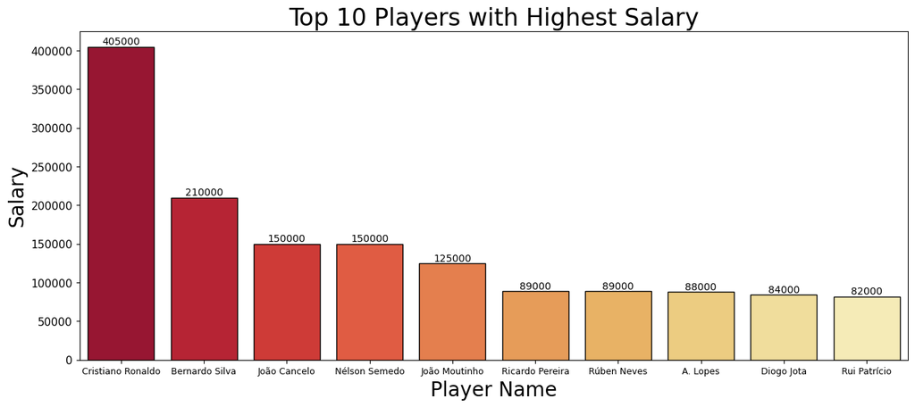

```python
plt.figure(figsize=(15,6))
plt.title('Top 10 Players with Highest Salary', color='black', fontsize=24)
plt.xticks(fontsize=9)
plt.yticks(fontsize=11)
plt.xlabel('', fontsize=20)
plt.ylabel('', fontsize=20)
Bar_Graph = pd.DataFrame(Portugal_Top_10)
Graph = sns.barplot(x='Short_Name', y='Wages_in_Euro', hue='Short_Name', data=Bar_Graph, palette='YlOrRd_r', edgecolor='black', dodge=False)
Graph.set(ylabel='Salary', xlabel='Player Name')
for container in Graph.containers:
    Graph.bar_label(container, fontsize=10)  # To get LABEL on EACH BAR.
plt.show()
```

7. To get the List of Top 10 Players based on thier Shooting Points.

```python
Player_Shooting= Data[['Short_Name','Shooting']].sort_values(by=['Shooting'],ascending=False).head(10)
Player_Shooting
```

|  | Short_Name | Shooting |
| --- | --- | --- |
| 1 | Cristiano Ronaldo | 93.0 |
| 0 | L. Messi | 92.0 |
| 12 | H. Kane | 91.0 |
| 17 | S. Agüero | 90.0 |
| 205 | F. Quagliarella | 89.0 |
| 19 | L. Suárez | 89.0 |
| 96 | Z. Ibrahimović | 88.0 |
| 37 | M. Reus | 88.0 |
| 100 | G. Bale | 87.0 |
| 20 | R. Lewandowski | 87.0 |

8. To get the List of Top 10 Players based on thier Defending Points.

```python
Player_Defending= Data[['Short_Name','Defending','Nationality','Club']].sort_values(by=['Defending'],ascending=False).head(10)
Player_Defending
```

|  | Short_Name | Defending | Nationality | Club |
| --- | --- | --- | --- | --- |
| 16 | G. Chiellini | 90.0 | Italy | Juventus |
| 7 | V. van Dijk | 90.0 | Netherlands | Liverpool |
| 11 | K. Koulibaly | 89.0 | Senegal | Napoli |
| 35 | D. Godín | 89.0 | Uruguay | Inter |
| 49 | M. Hummels | 89.0 | Germany | Borussia Dortmund |
| 29 | Piqué | 88.0 | Spain | FC Barcelona |
| 50 | T. Alderweireld | 88.0 | Belgium | Tottenham Hotspur |
| 40 | A. Laporte | 88.0 | France | Manchester City |
| 47 | J. Vertonghen | 87.0 | Belgium | Tottenham Hotspur |
| 67 | L. Bonucci | 87.0 | Italy | Juventus |

9)(i) To get the Details of all the Players belonging to the Most Famous 'REAL MADRID' Club.

```python
Real_Madrid=Data[Data['Club']=='Real Madrid']
Real_Madrid
```

|  | SI_NO | Player_URL | Short_Name | Long_Name | Age | Date_of_Birth | Height_cm | Weight_kg | Nationality | Club | ... | lwb | ldm | cdm | rdm | rwb | lb | lcb | cb | rcb | rb |
| --- | --- | --- | --- | --- | --- | --- | --- | --- | --- | --- | --- | --- | --- | --- | --- | --- | --- | --- | --- | --- | --- |
| 4 | 183277 | https://sofifa.com/player/183277/eden-hazard/2... | E. Hazard | Eden Hazard | 28 | 1/7/1991 | 175 | 74 | Belgium | Real Madrid | ... | 66+3 | 63+3 | 63+3 | 63+3 | 66+3 | 61+3 | 49+3 | 49+3 | 49+3 | 61+3 |
| 8 | 177003 | https://sofifa.com/player/177003/luka-modric/2... | L. Modrić | Luka Modrić | 33 | 9/9/1985 | 172 | 66 | Croatia | Real Madrid | ... | 81+3 | 81+3 | 81+3 | 81+3 | 81+3 | 79+3 | 72+3 | 72+3 | 72+3 | 79+3 |
| 18 | 155862 | https://sofifa.com/player/155862/sergio-ramos-... | Sergio Ramos | Sergio Ramos García | 33 | 3/30/1986 | 184 | 82 | Spain | Real Madrid | ... | 80+3 | 84+3 | 84+3 | 84+3 | 80+3 | 82+3 | 87+3 | 87+3 | 87+3 | 82+3 |
| 28 | 192119 | https://sofifa.com/player/192119/thibaut-court... | T. Courtois | Thibaut Courtois | 27 | 5/11/1992 | 199 | 96 | Belgium | Real Madrid | ... | NaN | NaN | NaN | NaN | NaN | NaN | NaN | NaN | NaN | NaN |
| 36 | 182521 | https://sofifa.com/player/182521/toni-kroos/20... | T. Kroos | Toni Kroos | 29 | 1/4/1990 | 183 | 76 | Germany | Real Madrid | ... | 75+3 | 79+3 | 79+3 | 79+3 | 75+3 | 72+3 | 69+3 | 69+3 | 69+3 | 72+3 |
| 42 | 200145 | https://sofifa.com/player/200145/carlos-henriq... | Casemiro | Carlos Henrique Venancio Casimiro | 27 | 2/23/1992 | 185 | 84 | Brazil | Real Madrid | ... | 78+3 | 84+3 | 84+3 | 84+3 | 78+3 | 79+3 | 84+3 | 84+3 | 84+3 | 79+3 |
| 46 | 165153 | https://sofifa.com/player/165153/karim-benzema... | K. Benzema | Karim Benzema | 31 | 12/19/1987 | 185 | 81 | France | Real Madrid | ... | 62+3 | 62+3 | 62+3 | 62+3 | 62+3 | 58+3 | 54+3 | 54+3 | 54+3 | 58+3 |
| 53 | 193041 | https://sofifa.com/player/193041/keylor-navas/... | K. Navas | Keylor Navas | 32 | 12/15/1986 | 185 | 80 | Costa Rica | Real Madrid | ... | NaN | NaN | NaN | NaN | NaN | NaN | NaN | NaN | NaN | NaN |
| 62 | 197781 | https://sofifa.com/player/197781/francisco-rom... | Isco | Francisco Román Alarcón Suárez | 27 | 4/21/1992 | 176 | 79 | Spain | Real Madrid | ... | 70+3 | 70+3 | 70+3 | 70+3 | 70+3 | 67+3 | 62+3 | 62+3 | 62+3 | 67+3 |
| 76 | 201535 | https://sofifa.com/player/201535/raphael-varan... | R. Varane | Raphaël Varane | 26 | 4/25/1993 | 191 | 81 | France | Real Madrid | ... | 74+3 | 79+3 | 79+3 | 79+3 | 74+3 | 77+3 | 83+3 | 83+3 | 83+3 | 77+3 |
| 94 | 204963 | https://sofifa.com/player/204963/daniel-carvaj... | Carvajal | Daniel Carvajal Ramos | 27 | 1/11/1992 | 173 | 73 | Spain | Real Madrid | ... | 83+3 | 82+3 | 82+3 | 82+3 | 83+3 | 83+3 | 80+3 | 80+3 | 80+3 | 83+3 |
| 100 | 173731 | https://sofifa.com/player/173731/gareth-bale/2... | G. Bale | Gareth Frank Bale | 29 | 7/16/1989 | 185 | 82 | Wales | Real Madrid | ... | 72+3 | 69+3 | 69+3 | 69+3 | 72+3 | 70+3 | 66+3 | 66+3 | 66+3 | 70+3 |
| 101 | 176676 | https://sofifa.com/player/176676/marcelo-vieir... | Marcelo | Marcelo Vieira da Silva Júnior | 31 | 5/12/1988 | 174 | 75 | Brazil | Real Madrid | ... | 82+3 | 81+3 | 81+3 | 81+3 | 82+3 | 81+3 | 79+3 | 79+3 | 79+3 | 81+3 |
| 106 | 198710 | https://sofifa.com/player/198710/james-rodrigu... | J. Rodríguez | James David Rodríguez Rubio | 27 | 7/12/1991 | 180 | 75 | Colombia | Real Madrid | ... | 67+3 | 67+3 | 67+3 | 67+3 | 67+3 | 62+3 | 57+3 | 57+3 | 57+3 | 62+3 |
| 161 | 232432 | https://sofifa.com/player/232432/luka-jovic/20... | L. Jović | Luka Jović | 21 | 12/23/1997 | 182 | 85 | Serbia | Real Madrid | ... | 55+2 | 53+2 | 53+2 | 53+2 | 55+2 | 51+2 | 47+2 | 47+2 | 47+2 | 51+2 |
| 178 | 220834 | https://sofifa.com/player/220834/marco-asensio... | Marco Asensio | Marco Asensio Willemsen | 23 | 1/21/1996 | 182 | 76 | Spain | Real Madrid | ... | 66+3 | 63+3 | 63+3 | 63+3 | 66+3 | 62+3 | 52+3 | 52+3 | 52+3 | 62+3 |
| 277 | 200724 | https://sofifa.com/player/200724/jose-ignacio-... | Nacho Fernández | José Ignacio Fernández Iglesias | 29 | 1/18/1990 | 180 | 76 | Spain | Real Madrid | ... | 77+2 | 76+2 | 76+2 | 76+2 | 77+2 | 78+2 | 80+2 | 80+2 | 80+2 | 78+2 |
| 332 | 240130 | https://sofifa.com/player/240130/eder-gabriel-... | Éder Militão | Éder Gabriel Militão | 21 | 1/18/1998 | 186 | 78 | Brazil | Real Madrid | ... | 78+2 | 76+2 | 76+2 | 76+2 | 78+2 | 78+2 | 79+2 | 79+2 | 79+2 | 78+2 |
| 403 | 208618 | https://sofifa.com/player/208618/lucas-vazquez... | Lucas Vázquez | Lucas Vázquez Iglesias | 28 | 7/1/1991 | 173 | 70 | Spain | Real Madrid | ... | 73+2 | 70+2 | 70+2 | 70+2 | 73+2 | 70+2 | 62+2 | 62+2 | 62+2 | 70+2 |
| 424 | 228618 | https://sofifa.com/player/228618/ferland-mendy... | F. Mendy | Ferland Mendy | 24 | 6/8/1995 | 180 | 73 | France | Real Madrid | ... | 78+2 | 77+2 | 77+2 | 77+2 | 78+2 | 78+2 | 76+2 | 76+2 | 76+2 | 78+2 |
| 437 | 234035 | https://sofifa.com/player/234035/alvaro-odrioz... | Odriozola | Álvaro Odriozola Arzalluz | 23 | 12/14/1995 | 176 | 66 | Spain | Real Madrid | ... | 79+2 | 74+2 | 74+2 | 74+2 | 79+2 | 79+2 | 74+2 | 74+2 | 74+2 | 79+2 |
| 568 | 238794 | https://sofifa.com/player/238794/vinicius-jose... | Vinícius Jr. | Vinícius José de Oliveira Júnior | 18 | 7/12/2000 | 176 | 73 | Brazil | Real Madrid | ... | 58+2 | 53+2 | 53+2 | 53+2 | 58+2 | 53+2 | 43+2 | 43+2 | 43+2 | 53+2 |
| 636 | 221639 | https://sofifa.com/player/221639/mariano-diaz-... | Mariano | Mariano Díaz Mejía | 25 | 8/1/1993 | 180 | 76 | Dominican Republic | Real Madrid | ... | 58+2 | 58+2 | 58+2 | 58+2 | 58+2 | 57+2 | 58+2 | 58+2 | 58+2 | 57+2 |
| 1009 | 239053 | https://sofifa.com/player/239053/federico-valv... | F. Valverde | Federico Valverde | 20 | 7/22/1998 | 182 | 78 | Uruguay | Real Madrid | ... | 67+2 | 72+2 | 72+2 | 72+2 | 67+2 | 66+2 | 65+2 | 65+2 | 65+2 | 66+2 |
| 1256 | 243812 | https://sofifa.com/player/243812/rodrygo-silva... | Rodrygo | Rodrygo Silva de Goes | 18 | 1/9/2001 | 174 | 64 | Brazil | Real Madrid | ... | 56+2 | 48+2 | 48+2 | 48+2 | 56+2 | 52+2 | 41+2 | 41+2 | 41+2 | 52+2 |
| 2286 | 209749 | https://sofifa.com/player/209749/lucas-silva-b... | Lucas Silva | Lucas Silva Borges | 26 | 2/16/1993 | 182 | 80 | Brazil | Real Madrid | ... | 70+2 | 72+2 | 72+2 | 72+2 | 70+2 | 69+2 | 71+2 | 71+2 | 71+2 | 69+2 |
| 2652 | 231410 | https://sofifa.com/player/231410/brahim-diaz/2... | Brahim | Brahim Díaz | 19 | 8/3/1999 | 171 | 68 | Spain | Real Madrid | ... | 52+2 | 47+2 | 47+2 | 47+2 | 52+2 | 47+2 | 37+2 | 37+2 | 37+2 | 47+2 |
| 4757 | 237681 | https://sofifa.com/player/237681/takefusa-kubo... | T. Kubo | 久保 建英 | 18 | 6/4/2001 | 173 | 67 | Japan | Real Madrid | ... | 57+2 | 52+2 | 52+2 | 52+2 | 57+2 | 55+2 | 45+2 | 45+2 | 45+2 | 55+2 |
| 5676 | 244523 | https://sofifa.com/player/244523/javier-hernan... | Javi Hernández | Javier Hernández Carrera | 21 | 5/2/1998 | 182 | 72 | Spain | Real Madrid | ... | 68+2 | 66+2 | 66+2 | 66+2 | 68+2 | 68+2 | 67+2 | 67+2 | 67+2 | 68+2 |
| 8777 | 245287 | https://sofifa.com/player/245287/sergio-lopez-... | Sergio López | Sergio López Galache | 20 | 4/8/1999 | 179 | 66 | Spain | Real Madrid | ... | 65+2 | 61+2 | 61+2 | 61+2 | 65+2 | 65+2 | 62+2 | 62+2 | 62+2 | 65+2 |
| 8898 | 246608 | https://sofifa.com/player/246608/alvaro-fidalg... | Fidalgo | Álvaro Fidalgo Fernández | 22 | 4/9/1997 | 175 | 68 | Spain | Real Madrid | ... | 58+2 | 59+2 | 59+2 | 59+2 | 58+2 | 56+2 | 52+2 | 52+2 | 52+2 | 56+2 |
| 9922 | 245290 | https://sofifa.com/player/245290/adrian-de-la-... | De la Fuente | Adrián de la Fuente | 20 | 2/22/1999 | 179 | 78 | Spain | Real Madrid | ... | 58+2 | 60+2 | 60+2 | 60+2 | 58+2 | 59+2 | 63+2 | 63+2 | 63+2 | 59+2 |
| 13116 | 247411 | https://sofifa.com/player/247411/diego-altube-... | Altube | Diego Altube Suárez | 19 | 2/22/2000 | 188 | 85 | Spain | Real Madrid | ... | NaN | NaN | NaN | NaN | NaN | NaN | NaN | NaN | NaN | NaN |

33 rows × 104 columns

9)(ii) To get the List of all the Nations Belonging to the Club 'REAL MADRID' .

```python
Real_Madrid['Nationality'].value_counts()
```

```
Nationality
Spain                 13
Brazil                 6
France                 3
Belgium                2
Croatia                1
Germany                1
Costa Rica             1
Wales                  1
Colombia               1
Serbia                 1
Dominican Republic     1
Uruguay                1
Japan                  1
Name: count, dtype: int64
```

9)(iii) To Plot the Graph.

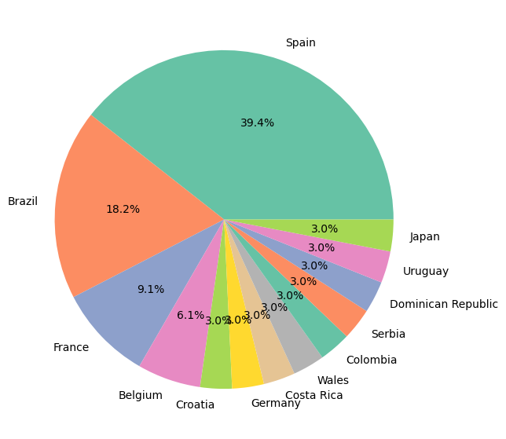

```python
plt.figure(figsize=(7,7))
Batting_First_Plot=list(Real_Madrid['Nationality'].value_counts().keys())
Counts=list(Real_Madrid['Nationality'].value_counts())
plt.pie(Counts,labels=Batting_First_Plot,colors=sns.color_palette('Set2'),autopct='%0.1f%%')
plt.show()
```

9)(iv) To get the Details of TOP 10 Players Belonging to the Club 'REAL MADRID' based on thier SALARY.

```python
Players_Salaries = Real_Madrid[['Short_Name','Wages_in_Euro','Nationality','Club']].sort_values(by=['Wages_in_Euro'],ascending=False).head(10)
Players_Salaries
```

|  | Short_Name | Wages_in_Euro | Nationality | Club |
| --- | --- | --- | --- | --- |
| 4 | E. Hazard | 470000 | Belgium | Real Madrid |
| 8 | L. Modrić | 340000 | Croatia | Real Madrid |
| 36 | T. Kroos | 330000 | Germany | Real Madrid |
| 18 | Sergio Ramos | 300000 | Spain | Real Madrid |
| 46 | K. Benzema | 285000 | France | Real Madrid |
| 100 | G. Bale | 250000 | Wales | Real Madrid |
| 62 | Isco | 245000 | Spain | Real Madrid |
| 42 | Casemiro | 240000 | Brazil | Real Madrid |
| 28 | T. Courtois | 235000 | Belgium | Real Madrid |
| 106 | J. Rodríguez | 225000 | Colombia | Real Madrid |

9)(v) To Plot the Graph.

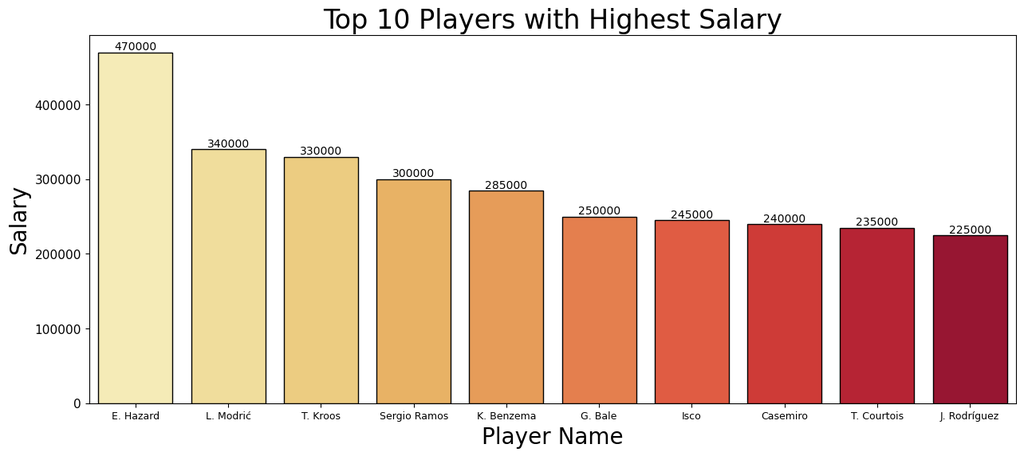

```python
plt.figure(figsize=(15,6))
plt.title('Top 10 Players with Highest Salary', color='black', fontsize=24)
plt.xticks(fontsize=9)
plt.yticks(fontsize=11)
plt.xlabel('', fontsize=20)
plt.ylabel('', fontsize=20)
Bar_Graph = pd.DataFrame(Players_Salaries)
Graph = sns.barplot(x='Short_Name', y='Wages_in_Euro', hue='Short_Name', data=Bar_Graph, palette='YlOrRd', edgecolor='black', dodge=False)
Graph.set(ylabel='Salary', xlabel='Player Name')
for container in Graph.containers:
    Graph.bar_label(container, fontsize=10)  # To get LABEL on EACH BAR.
plt.show()
```

9)(vi) To get the Details of TOP 10 Players Belonging to the Club 'REAL MADRID' based on thier SHOOTING Points.

```python
Players_Shooting = Real_Madrid[['Short_Name','Shooting','Nationality','Club']].sort_values(by=['Shooting'],ascending=False).head(10)
Players_Shooting
```

|  | Short_Name | Shooting | Nationality | Club |
| --- | --- | --- | --- | --- |
| 100 | G. Bale | 87.0 | Wales | Real Madrid |
| 106 | J. Rodríguez | 86.0 | Colombia | Real Madrid |
| 4 | E. Hazard | 83.0 | Belgium | Real Madrid |
| 46 | K. Benzema | 82.0 | France | Real Madrid |
| 161 | L. Jović | 82.0 | Serbia | Real Madrid |
| 36 | T. Kroos | 80.0 | Germany | Real Madrid |
| 178 | Marco Asensio | 80.0 | Spain | Real Madrid |
| 636 | Mariano | 80.0 | Dominican Republic | Real Madrid |
| 62 | Isco | 77.0 | Spain | Real Madrid |
| 8 | L. Modrić | 76.0 | Croatia | Real Madrid |

9)(vii) To get the Details of TOP 10 Players Belonging to the Club 'REAL MADRID' based on thier DEFENDING Points.

```python
Players_Defending = Real_Madrid[['Short_Name','Defending','Nationality','Club']].sort_values(by=['Defending'],ascending=False).head(10)
Players_Defending
```

|  | Short_Name | Defending | Nationality | Club |
| --- | --- | --- | --- | --- |
| 18 | Sergio Ramos | 87.0 | Spain | Real Madrid |
| 42 | Casemiro | 85.0 | Brazil | Real Madrid |
| 76 | R. Varane | 85.0 | France | Real Madrid |
| 94 | Carvajal | 82.0 | Spain | Real Madrid |
| 332 | Éder Militão | 81.0 | Brazil | Real Madrid |
| 277 | Nacho Fernández | 81.0 | Spain | Real Madrid |
| 101 | Marcelo | 77.0 | Brazil | Real Madrid |
| 437 | Odriozola | 77.0 | Spain | Real Madrid |
| 424 | F. Mendy | 75.0 | France | Real Madrid |
| 8 | L. Modrić | 72.0 | Croatia | Real Madrid |